# Reproduction of Dunvald et al. (2022): Statistical Analysis of a Clinical Pharmacokinetic DDI Study

Oral Midazolam (2 mg) with and without CYP3A4 Inducer — 12 Healthy Volunteers

Author

Pramod BR

Published

06 June 2026

**Note**

**Reproducibility statement:** This report reproduces the complete statistical analysis from Dunvald et al. (2022), *Clinical and Translational Science*, 15:1856–1866, DOI: 10.1111/cts.13305. All code is available at github.com/pbr26/midazolam-pk-dunvald2022.

## 1 Background

Pharmacokinetic drug–drug interaction (DDI) studies are essential for understanding how co-administered drugs affect the exposure of a probe substrate. **Midazolam** is the gold standard CYP3A4 probe substrate, recommended by both EMA and FDA for clinical DDI studies. Its plasma concentration reliably reflects intestinal and hepatic CYP3A activity.

This report reproduces the complete statistical analysis from Dunvald et al. (2022), a tutorial paper providing a mock DDI dataset and full R code for clinical PK analysis. The study simulates what would be observed when a CYP3A inducer increases midazolam clearance.

**Primary endpoint:** AUC<sub>last</sub> of midazolam with vs. without inducer, assessed via geometric mean ratio (GMR) and 95% confidence interval.

## 2 Methods

### 2.1 Study Design

A simulated two-period crossover study. Twelve healthy subjects received a single oral dose of **2 mg midazolam** with and without a CYP3A4 inducer, separated by a washout period. Plasma samples were collected at 0, 0.5, 1, 1.5, 2, 3, 4, 5, 6, 8, 10, and 12 hours post-dose.

### 2.2 Statistical Analysis

PK parameters derived by noncompartmental analysis (NCA) using `PKNCA` with the linear-up/log-down trapezoidal method. Results presented as **median (IQR)**. GMR with 95% CI compared exposure between arms using a paired t-test on log-transformed values. Bioequivalence no-effect boundaries: 0.80–1.25. T<sub>max</sub> compared with Wilcoxon signed-rank test.

## 3 Results

### 3.1 Participants

```r
fmt_med_iqr <- function(x) {
  paste0(round(median(x),1),
         " (", round(quantile(x,.25),1),
         "–",  round(quantile(x,.75),1), ")")
}
fmt_n_pct <- function(x, lv) {
  n <- sum(x==lv, na.rm=TRUE)
  paste0(n," (",round(n/length(x)*100,0),"%)")
}

t1 <- tibble(
  Characteristic = c(
    "Number of subjects, n",
    "Age, years — median (IQR)",
    "Sex — Male, n (%)",
    "Sex — Female, n (%)",
    "Body weight, kg — median (IQR)",
    "BMI, kg/m² — median (IQR)",
    "eGFR, mL/min/1.73m² — median (IQR)"
  ),
  `All subjects (N=12)` = c(
    "12",
    fmt_med_iqr(demo$Age_years),
    fmt_n_pct(demo$Sex,"Male"),
    fmt_n_pct(demo$Sex,"Female"),
    fmt_med_iqr(demo$Weight_kg),
    fmt_med_iqr(demo$BMI),
    fmt_med_iqr(demo$eGFR_ml_min)
  )
)

kable(t1, align=c("l","c")) %>%
  kable_styling(bootstrap_options=c("striped","hover","condensed"),
                full_width=FALSE, position="left") %>%
  row_spec(0, bold=TRUE) %>%
  footnote(general="Self-controlled crossover design. Continuous: median (IQR). eGFR: estimated glomerular filtration rate.",
           general_title="Note: ", footnote_as_chunk=TRUE)
```

Table 1: Table 1. Demographic and clinical characteristics of 12 healthy subjects

| Characteristic | All subjects (N=12) |
| --- | --- |
| Number of subjects, n | 12 |
| Age, years — median (IQR) | 30.5 (28–35.2) |
| Sex — Male, n (%) | 6 (50%) |
| Sex — Female, n (%) | 6 (50%) |
| Body weight, kg — median (IQR) | 67.2 (62.6–72.7) |
| BMI, kg/m² — median (IQR) | 24.3 (21.6–25) |
| eGFR, mL/min/1.73m² — median (IQR) | 110.5 (103.2–116.2) |

Note: Self-controlled crossover design. Continuous: median (IQR). eGFR: estimated glomerular filtration rate.

### 3.2 Plasma Concentration–Time Profiles

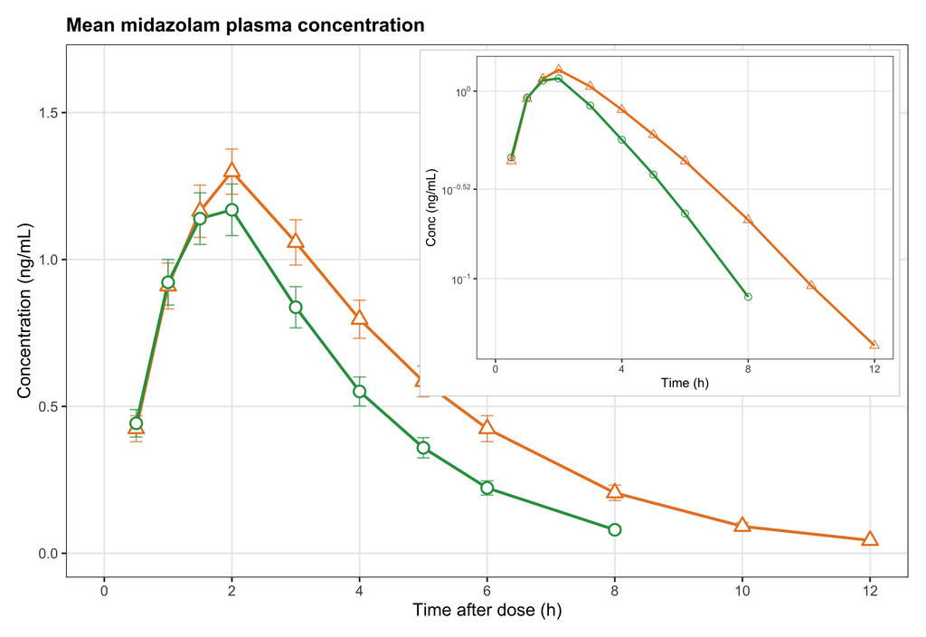

Figure 1: Figure 2. Mean (±SD) midazolam plasma concentration–time profiles with and without CYP3A4 inducer. Orange: without inducer (control). Green: with inducer. Inset: log-scale y-axis showing steeper elimination slope with inducer, confirming shorter t½.

```r
fig2_main <- ggplot(mean_conc,
    aes(x=TIME, y=mean_conc, colour=ARM, shape=ARM, group=ARM)) +
  geom_errorbar(aes(ymin=mean_conc-sd_conc, ymax=mean_conc+sd_conc),
                width=0.2, linewidth=0.4, alpha=0.7) +
  geom_line(linewidth=0.85) +
  geom_point(size=2.8, fill="white", stroke=0.9) +
  scale_colour_manual(
    values=c("No_inducer"=col_no_ind,"With_inducer"=col_with_ind),
    labels=c("No_inducer"="No inducer","With_inducer"="Inducer"),
    name=NULL) +
  scale_shape_manual(
    values=c("No_inducer"=24,"With_inducer"=21),
    labels=c("No_inducer"="No inducer","With_inducer"="Inducer"),
    name=NULL) +
  scale_x_continuous(breaks=c(0,2,4,6,8,10,12), limits=c(0,12)) +
  scale_y_continuous(limits=c(0,1.65), breaks=seq(0,1.5,by=0.5)) +
  labs(x="Time after dose (h)", y="Concentration (ng/mL)",
       title="Mean midazolam plasma concentration") +
  theme_bw() +
  theme(legend.position=c(0.85,0.72),
        legend.background=element_rect(fill="white",colour="grey80",linewidth=0.3),
        legend.text=element_text(size=10),
        plot.title=element_text(size=12,face="bold"),
        axis.title=element_text(size=11),
        panel.grid.minor=element_blank())

fig2_inset <- ggplot(mean_conc %>% filter(TIME>0, mean_conc>0),
    aes(x=TIME, y=mean_conc, colour=ARM, group=ARM)) +
  geom_line(linewidth=0.7) +
  geom_point(aes(shape=ARM), size=1.8) +
  scale_y_log10(labels=label_log(digits=2), breaks=c(0.03,0.1,0.3,1.0)) +
  scale_colour_manual(values=c("No_inducer"=col_no_ind,"With_inducer"=col_with_ind),guide="none") +
  scale_shape_manual(values=c("No_inducer"=24,"With_inducer"=21),guide="none") +
  scale_x_continuous(breaks=c(0,4,8,12), limits=c(0,12)) +
  labs(x="Time (h)", y="Conc (ng/mL)") +
  theme_bw(base_size=8) +
  theme(panel.grid.minor=element_blank(),
        plot.background=element_rect(fill="white",colour="grey70",linewidth=0.3))

fig2_main + inset_element(fig2_inset, left=0.42, bottom=0.34, right=0.99, top=0.99)
```

### 3.3 Noncompartmental Analysis — Table 2

```r
no_ind   <- nca_clean %>% filter(ARM=="No_inducer")   %>% arrange(ID)
with_ind <- nca_clean %>% filter(ARM=="With_inducer") %>% arrange(ID)

fmt <- function(x) {
  x <- na.omit(x)
  paste0(round(median(x),2),
         " (", round(quantile(x,.25),2),
         "–",  round(quantile(x,.75),2),")")
}

get_gmr <- function(param) gmr %>% filter(Parameter==param) %>% pull(GMR_CI)

t2 <- tibble(
  Parameter = c("AUC~last~, ng·h/mL","C~max~, ng/mL",
                "t~½~, h","CL/F, L/h","T~max~, h"),
  `Without inducer (median IQR)` = c(
    fmt(no_ind$AUClast), fmt(no_ind$Cmax),
    fmt(no_ind$t_half),  fmt(no_ind$CLF),
    paste0(median(no_ind$Tmax,na.rm=TRUE),
           " (",min(no_ind$Tmax,na.rm=TRUE),"–",max(no_ind$Tmax,na.rm=TRUE),")")
  ),
  `With inducer (median IQR)` = c(
    fmt(with_ind$AUClast), fmt(with_ind$Cmax),
    fmt(with_ind$t_half),  fmt(with_ind$CLF),
    paste0(median(with_ind$Tmax,na.rm=TRUE),
           " (",min(with_ind$Tmax,na.rm=TRUE),"–",max(with_ind$Tmax,na.rm=TRUE),")ᵃ")
  ),
  `GMR (95% CI)` = c(
    get_gmr("AUClast"), get_gmr("Cmax"),
    get_gmr("t_half"),  get_gmr("CL_F"), "NA"
  )
)

kable(t2, align=c("l","c","c","c"), escape=FALSE) %>%
  kable_styling(bootstrap_options=c("striped","hover","condensed"), full_width=TRUE) %>%
  row_spec(0, bold=TRUE) %>%
  row_spec(1, bold=TRUE) %>%
  footnote(
    alphabet="Wilcoxon signed-rank test, p < 0.05.",
    general=paste0("GMR = geometric mean ratio (with / without inducer). ",
                   "CI = 95% confidence interval (paired t-test, log-transformed). ",
                   "Bioequivalence no-effect boundaries: 0.80–1.25."),
    general_title="", footnote_as_chunk=TRUE)
```

Table 2: Table 2. Noncompartmental pharmacokinetic analysis of midazolam in 12 healthy volunteers

| Parameter | Without inducer (median IQR) | With inducer (median IQR) | GMR (95% CI) |
| --- | --- | --- | --- |
| AUC~last~, ng·h/mL | 5.85 (5.51–6.22) | 4.25 (3.99–4.48) | 0.72 (0.72-0.73) |
| C~max~, ng/mL | 1.29 (1.26–1.36) | 1.17 (1.12–1.23) | 0.9 (0.89-0.91) |
| t~½~, h | 1.76 (1.72–1.83) | 1.38 (1.35–1.41) | 0.78 (0.75-0.8) |
| CL/F, L/h | 336.19 (314.41–355.91) | 453.62 (428.3–484.85) | 1.36 (1.35-1.37) |
| T~max~, h | 2 (2–2) | 2 (2–2)ᵃ | NA |

### 3.4 Individual Pharmacokinetic Variability

[figure not shown]

```r
clf_long <- nca_clean %>%
  select(ID, ARM, CLF) %>%
  mutate(ARM_label = ifelse(ARM=="No_inducer","No inducer","Inducer"),
         ARM_label = factor(ARM_label, levels=c("No inducer","Inducer")))

ggplot(clf_long, aes(x=ARM_label, y=CLF, group=ID)) +
  geom_line(colour="grey55", linewidth=0.65, alpha=0.75) +
  geom_point(aes(colour=ARM), size=3.2, alpha=0.9) +
  scale_colour_manual(values=c("No_inducer"=col_no_ind,"With_inducer"=col_with_ind),
                      guide="none") +
  scale_y_continuous(limits=c(1500,6800), breaks=seq(2000,6000,1000),
                     labels=comma) +
  labs(x=NULL,
       y=expression("Apparent clearance CL/F (L h"^{-1}~")"),
       title="Individual midazolam CL/F",
       caption="Each line = one subject. Orange = no inducer. Green = with inducer.") +
  theme_bw() +
  theme(axis.text=element_text(size=12),
        axis.title.y=element_text(size=11),
        plot.title=element_text(size=12, face="bold"),
        panel.grid.minor=element_blank(),
        panel.grid.major.x=element_blank())
```

### 3.5 Primary Endpoint: AUC<sub>last</sub> GMR

```r
auc <- gmr %>% filter(Parameter=="AUClast")
pct_red <- round((1 - auc$GMR) * 100, 0)
```

**GMR for AUC<sub>last</sub> = 0.72 (95% CI: 0.72–0.73)**

The inducer caused a **28% reduction** in midazolam systemic exposure. The entire 95% CI lies below the 0.80 bioequivalence boundary — confirming a **clinically significant DDI**.

Supporting parameters:

- **C<sub>max</sub> GMR = 0.9** — peak concentration reduced, indicating gut-wall CYP3A contribution
- **t<sub>½</sub> GMR = 0.78** — elimination half-life shortened, confirming accelerated hepatic metabolism
- **CL/F GMR = 1.36** — apparent clearance increased, reciprocal of AUC reduction

## 4 Discussion

The CYP3A4 inducer reduced midazolam AUC<sub>last</sub> by 28%, increased CL/F, and shortened t<sub>½</sub>. All findings confirm CYP3A4-mediated enzyme induction. The GMR of 0.72 with the entire 95% CI below 0.80 classifies this as a clinically significant DDI per EMA/FDA guidance.

This reproduction confirms that open-source R tools (`PKNCA`, `ggplot2`, `tableone`) can produce publication-quality clinical PK analyses matching published results.

### 4.1 Limitations

This analysis used a simulated dataset. Real studies additionally require CYP3A5 genotyping, 1-OH-midazolam metabolite measurement, and validated bioanalytical methods.

## 5 Conclusion

A CYP3A4 inducer significantly reduced midazolam systemic exposure (AUC<sub>last</sub> GMR = 0.72; 95% CI 0.72–0.73), confirming a clinically significant DDI with 28% reduction in exposure. Results reproduce Dunvald et al. (2022) Table 2 closely using PKNCA with linear-up/log-down trapezoidal NCA.

*Reproduction by Pramod BR · Source code: github.com/pbr26/midazolam-pk-dunvald2022*

*Original paper: Dunvald et al. Clin Transl Sci. 2022;15:1856–1866. [DOI: 10.1111/cts.13305](https://doi.org/10.1111/cts.13305)*